# Analisi Multilivello dell’Eurovision 2021: Network Science e Text Mining

Studio Strutturale del Televoto e Mappatura Concettuale dei Testi Musicali

Lorenza Cecere

# 1 INTRODUZIONE E OBIETTIVI DELLO STUDIO

Il presente lavoro si propone di analizzare l’edizione dell’**Eurovision Song Contest 2021** attraverso un duplice approccio computazionale radicato nelle scienze dei dati sociali:

1. **Network Science:** Studio del grafo dei flussi di voto del televoto pubblico per mappare alleanze geopolitiche, centralità nazionali e la tendenza intrinseca del network a frammentarsi in macro-comunità.
2. **Text Mining:** Sentiment Analysis dei testi delle tre finaliste (tradotti uniformemente in inglese) per estrarre e visualizzare graficamente la mappa concettuale dei temi universali trattati dagli artisti. Al fine di esaminare le relazioni di associazione tra gli artisti e i profili emotivi, è stata applicata un’Analisi delle Corrispondenze.

# 2 PARTE I: NETWORK SCIENCE: L’ANALISI DEL TELEVOTO

## 2.1 Caricamento dei Dataset e Data Pre-Processing

I dati grezzi documentano ogni singola transazione di voto dal 1957 al 2021. Al fine di preservare la significatività statistica e la sincronia temporale, isoliamo l’anno **2021**, estraendo esclusivamente la matrice del **Televoto** (voto espresso dal pubblico sovrano), escludendo le giurie tecniche per far emergere i legami socio-culturali puri tra le popolazioni.

## 2.2 Costruzione della Rete e Misure Globali

Un grafo è definito dalla coppia $G = (V, E)$, dove $V$ rappresenta l’insieme dei nodi (le nazioni) ed $E$ l’insieme degli archi (i flussi di punteggio). Poiché il voto si muove da una nazione ad un’altra, la nostra rete è **direzionata e pesata** ($w_{ij} \in \{1..12\}$).

- **Densità ($\delta$):** Rapporto tra archi presenti e archi potenziali. Misura il livello di saturazione relazionale del sistema.
- **Diametro ($D$):** La massima distanza geodetica (il cammino minimo più lungo) tra qualsiasi coppia di nodi. Indica l’estensione dello spazio di rete.
- **Average Path Length:** La media dei cammini minimi tra tutti i nodi, indicatore dell’efficienza di propagazione dei flussi all’interno della rete.
- **Transitività (Clustering Coefficient Globale):** Misura la frazione di triadi chiuse.

Generiamo ora una tabella sintetica utilizzando la libreria `gt` per documentare l’anatomia del grafo.

**ANATOMIA STRUTTURALE DEL NETWORK GLOBALE**

| Metrica | Valore | Significato |
| --- | --- | --- |
| Stati Partecipanti (Nodi) | 28,00 | Nazioni attive nel calcolo del televoto |
| Voti (Archi) | 250,00 | Legami di punteggio effettivi (> 0) |
| Densità del Network | 0,33 | Percentuale di legami esistenti rispetto ai legami potenziali |
| Grado Medio (Connessioni) | 17,86 | Voti medi ricevuti per singolo Stato |
| Diametro Strutturale | 3,00 | Massima distanza geodetica per collegare due Stati nella rete |
| Shortest Path Medio | 1,61 | Numero medio di archi che separano una coppia di Stati |
| Transitività Globale (Clustering) | 0,68 | Propensione intrinseca a creare clique o blocchi regionali |
| Accentramento (In-Degree Centralization) | 0,56 | Livello di polarizzazione dei voti sui Paesi vincitori |

## 2.3 Misure di Centralità Locale

Mentre le misure globali descrivono il sistema nel suo complesso, le misure di centralità ne identificano i nodi strategici, catturando diverse sfumature del concetto di “potere” e “influenza”:

1. **In-Degree Centrality ($C_D^{in}(i)$):** Il numero di archi entranti in un nodo. Nel nostro contesto simboleggia l’attrattività e il successo di mercato della proposta musicale, ovvero la *popolarità immediata*.
2. **Out-Degree Centrality ($C_D^{out}(i)$):** Il numero di archi uscenti. All’Eurovision ogni paese esprime un numero fisso di preferenze, dunque l’out-degree riflette l’attività regolamentata di voto.
3. **Closeness Centrality ($C_C(i)$):** Il reciproco della somma delle distanze minime da tutti gli altri nodi:
   $$C_C(i) = \frac{1}{\sum_{j} d(i,j)}$$
   In una rete di voto esprime la capacità di un nodo di essere strutturalmente “vicino” a tutti i flussi transnazionali, agendo da recettore rapido dei consensi.
4. **Betweenness Centrality ($C_B(i)$):** La frequenza con cui un nodo si trova sui cammini minimi che collegano tutte le coppie di altri nodi della rete:
   $$C_B(i) = \sum_{s \neq i
   \neq t} \frac{\sigma_{st}(i)}{\sigma_{st}}$$
   Rappresenta il concetto sociologico di **“intermediario”**. Un nodo con alta betweenness agisce come un ponte tra sotto-componenti o cluster regionali isolati.

Eseguiamo ora il calcolo delle metriche su base locale ed estraiamo la **Top 10** dei paesi dominanti secondo il televoto del 2021.

**TOP 10 NAZIONI - RANKING DI CENTRALITÀ LOCALE**

| Stato | In-Degree | Out-Degree | Closeness | Betweenness |
| --- | --- | --- | --- | --- |
| Finland | 24 | 10 | 0.0417 | 17.5158 |
| Ukraine | 24 | 10 | 0.0417 | 28.6960 |
| France | 24 | 10 | 0.0417 | 36.7332 |
| Italy | 24 | 10 | 0.0417 | 50.8113 |
| Switzerland | 21 | 10 | 0.0370 | 30.0462 |
| Iceland | 17 | 10 | 0.0323 | 14.3936 |
| Lithuania | 16 | 10 | 0.0312 | 13.9687 |
| Russia | 14 | 10 | 0.0294 | 29.5559 |
| Sweden | 13 | 10 | 0.0286 | 9.6432 |
| Malta | 9 | 10 | 0.0256 | 14.5421 |

L’analisi dei parametri locali rivela dinamiche strutturali e geopolitiche di estremo interesse. In primo luogo, il valore di Out-Degree costantemente pari a 10 per tutti i paesi riflette un vincolo regolamentare istituzionale dell’Eurovision (l’obbligo di assegnare punti - da 1 a 12 - a una specifica top 10), configurando la rete, dal punto di vista della Network Science, con una proprietà di out-degree regolare. Analizzando il blocco di testa composto da Finlandia, Ucraina, Francia e Italia, si nota come queste quattro nazioni condividano lo stesso identico valore di In-Degree (24) e di Closeness Centrality (0.0417), indicando il medesimo livello di popolarità assoluta e di efficacia nel ricevere preferenze. Tuttavia, il vero elemento discriminante emerge dall’analisi della Betweenness Centrality, dove l’Italia svetta drammaticamente sopra gli altri sfidanti con un punteggio di 50.8113, a fronte del 17.5158 della Finlandia e del 28.6960 dell’Ucraina. In termini geopolitici e sociologici, questa firma topologica dimostra che i voti ottenuti dall’Italia non sono rimasti circoscritti a un blocco geografico isolato o a storiche alleanze regionali (come i blocchi dell’Est o del Nord Europa), ma si sono distribuiti in modo estremamente eterogeneo e trasversale nell’intera rete, posizionando l’Italia come il vero core-node.

### 2.3.1 Visualizzazione del Neighbourhood con Lollipop Chart

Per comprendere analiticamente da quali vettori geografici è dipesa la vittoria dell’Italia nel 2021 (i Måneskin), isoliamo il suo **In-Neighborhood** (il vicinato d’entrata), ovvero l’insieme delle nazioni che hanno indirizzato un arco verso il nodo “Italy”, pesando il legame con l’intensità del punteggio effettivo assegnato.

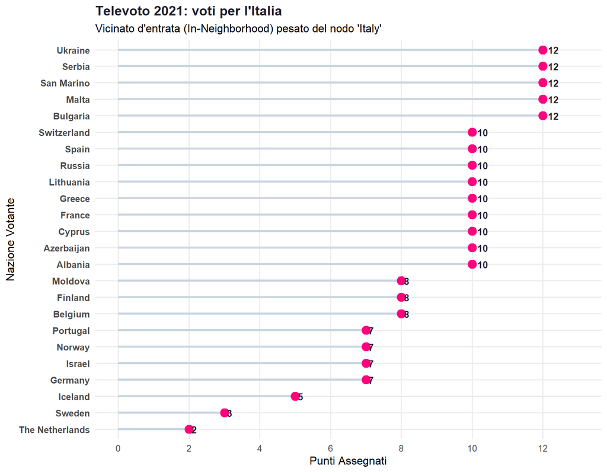

L’output grafico evidenzia una distribuzione del consenso eccezionalmente solida e stratificata: ben cinque paesi (Ucraina, Serbia, San Marino, Malta e Bulgaria) hanno assegnato all’Italia il punteggio massimo di 12 punti, seguiti da un nucleo massiccio di ben nove nazioni ancorate stabilmente sulla soglia dei 10 punti (tra cui Svizzera, Spagna, Russia e Francia).

Dal punto di vista della Network Science, il grafico non mostra un consenso polarizzato o limitato a cluster regionali isolati, bensì un fenomeno di convergenza trans-europea in cui diverse nazioni dell’Europa centrale concorrono in modo sinergico al peso complessivo del nodo italiano.

### 2.3.2 Edge Betweenness Centrality

Non sono solo i nodi a possedere un valore di centralità. La **Edge Betweenness Centrality** è una metrica della teoria delle reti che misura l’importanza di un arco in base a quanti cammini minimi (shortest path) tra tutte le coppie di nodi lo attraversano.

**CRITICAL BRIDGES: TOP 5 EDGE BETWEENNESS**

| Stato Votante | Stato Votato | Valore Edge Betweenness |
| --- | --- | --- |
| Russia | Cyprus | 25.00 |
| Italy | San Marino | 20.00 |
| Italy | Albania | 19.77 |
| Switzerland | Albania | 18.22 |
| France | Israel | 17.66 |

I risultati emersi dalla Top 5 Edge Betweenness dell’edizione 2021 evidenziano la spina dorsale geopolitica della manifestazione. Il legame Russia $\rightarrow$ Cyprus (25.00) si configura come l’arteria più trafficata dell’intero grafo, formalizzando il principale canale di comunicazione e convergenza culturale tra l’area post-sovietica e il bacino del Mediterraneo orientale. Di fondamentale rilievo è la duplice presenza dell’Italia nei primi tre vettori d’istanza, attraverso i legami diretti verso San Marino (20.00) e Albania (19.77). Questo dato dimostra che le preferenze espresse dall’Italia nel 2021 non hanno rappresentato semplici voti isolati o vicoli ciechi topologici; al contrario, agganciandosi a nodi strategici e altamente connessi come il micro-stato sammarinese e l’area balcanica, le scelte dell’Italia hanno funzionato come veri e propri vettori di instradamento culturale. Esse hanno permesso di accorciare le distanze geometriche globali e di connettere l’Europa occidentale con i cluster storici dell’Est e del Sud-Est europeo, confermando come l’equilibrio e l’interconnessione dell’intero festival abbiano gravitato attorno alle scelte relazionali del nodo italiano.

## 2.4 Community Detection

La ricerca di sottostrutture di comunità (clustering) risponde all’esigenza di comprendere come i nodi si aggreghino spontaneamente. Mettiamo a confronto quattro approcci teorici differenti della Network Science:

1. **Algoritmo di Louvain (`cluster_louvain`):** Approccio che punta a massimizzare l’indice di **Modularità ($Q$)**. La modularità misura la frazione di archi interni ai cluster rispetto a una rete generata casualmente:
   $$Q = \frac{1}{2m} \sum_{ij}
   \left[ A_{ij} - \frac{k_i k_j}{2m} \right] \delta(c_i, c_j)$$
   È un algoritmo greedy ultra-rapido, ideale per individuare macro-aggregazioni nette.
2. **Algoritmo Walktrap (`cluster_walktrap`):** Si basa sul principio dei **cammini casuali (Random Walks)**. L’assunto teorico è che un camminatore casuale che si muove lungo gli archi della rete tenderà a rimanere intrappolato a lungo all’interno di zone densamente connesse (le comunità), faticando a uscirne a causa della scarsità di ponti esterni.
3. **Algoritmo di Girvan-Newman (`cluster_edge_betweenness`):** Approccio divisivo gerarchico (top-down). Calcola ripetutamente la Edge Betweenness, individua l’arco ponte massimo, lo taglia e ricalcola le metriche, procedendo in modo iterativo fino a isolare i nodi. Svela la struttura ad albero (dendrogramma).
4. **Label Propagation (`cluster_label_prop`):** Ogni nazione adotta iterativamente la categoria statistica più frequente (la regola della maggioranza) presente nel proprio vicinato relazionale.Questo flusso simula la propagazione di un’influenza culturale o di un comportamento d’opinione all’interno del network.

Al fine di rendere i grafi simmetrici e idonei all’applicazione rigorosa di questi algoritmi, convertiamo la rete in **non-direzionata**, collassando gli archi contrapposti e sommandone i pesi relazionali.

### 2.4.1 Visualizzazione Grafica Comparativa degli Algoritmi

Visualizziamo contemporaneamente le 4 ripartizioni spaziali della rete.

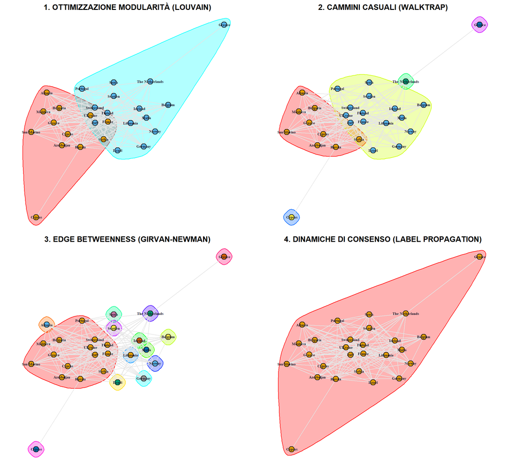

### 2.4.2 Grafico di Sovrapposizione Diretta

Per evidenziare i punti esatti di disaccordo tra i due modelli dominanti, generiamo un grafo integrato in cui **il colore interno del nodo mappa Louvain**, mentre **il colore del bordo esterno mappa Walktrap**. Se un nodo presenta un bordo di colore differente rispetto al nucleo interno, significa che i due algoritmi lo hanno assegnato a due cluster geopolitici diversi.

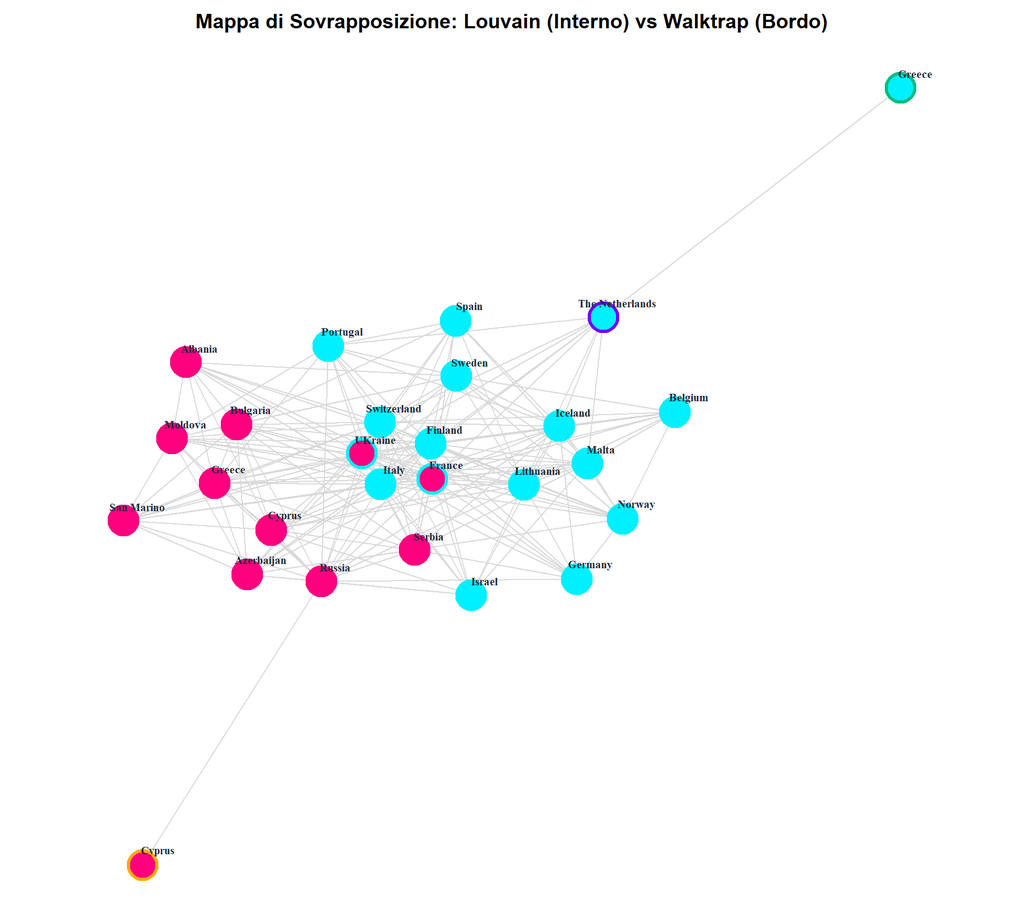

### 2.4.3 Analisi Comparativa delle Performance di Modularità ($Q$)

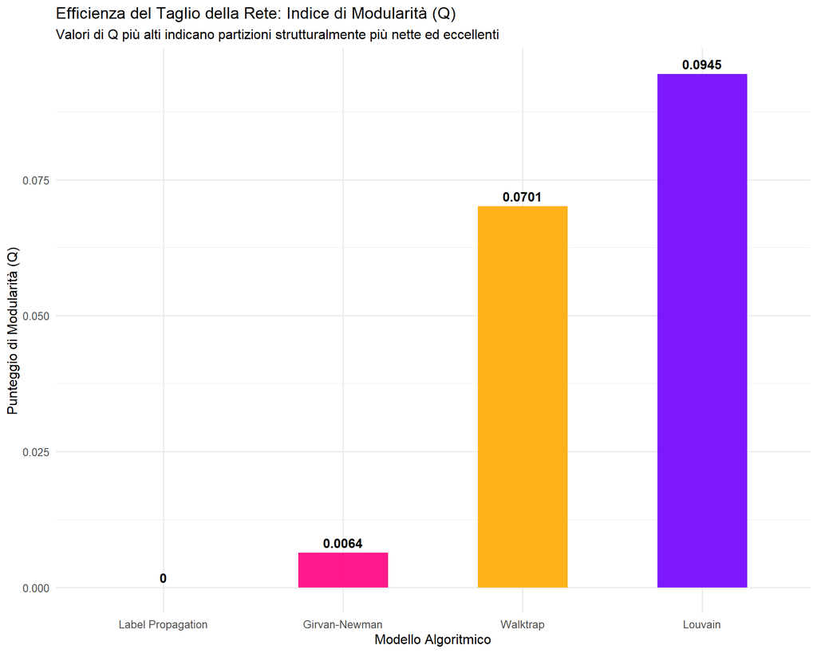

## 2.5 Metriche di Confronto e Distanza tra Partizioni

Per misurare rigorosamente se due algoritmi hanno generato lo stesso raggruppamento o se sussistono discrepanze macroscopiche, la Network Science si avvale di indici di informazione e distanza:

- **NMI (Normalized Mutual Information):** Misura l’informazione condivisa tra le partizioni. Varia tra $0$ (indipendenza totale dei cluster) e $1$ (accordo perfetto delle appartenenze).
- **ARI (Adjusted Rand Index):** Calcola la frazione di coppie di nodi inserite nello stesso cluster in entrambe le configurazioni, normalizzata rispetto al caso casuale. $1$ indica identità assoluta.
- **VI (Variation of Information):** Una vera e propria metrica di distanza basata sull’entropia d’informazione:
  $$VI(X,Y) = H(X) + H(Y) - 2I(X,Y)$$
  Misura quanta informazione si perde o si guadagna passando da una partizione all’altra. Valori vicini a $0$ indicano estrema stabilità strutturale.
- **Split-Join Distance:** Conta il numero minimo di nodi che devono essere spostati da una comunità all’altra per rendere le due partizioni perfettamente identiche.

Eseguiamo il confronto analitico focalizzandoci sui due modelli cardine: **Louvain** vs **Walktrap**.

**PROFILO DI DISTANZA E SIMILARITÀ TRA LE PARTIZIONI**

*Modello Louvain vs Modello Walktrap*

| Indice di Confronto Bilaterale | Valore Calcolato | Significato Analitico nel Network |
| --- | --- | --- |
| Normalized Mutual Information | 0.5370 | Grado di informazione condivisa: indica che i modelli estraggono i medesimi macro-blocchi relazionali. |
| Adjusted Rand Index | 0.7664 | Percentuale di accordo nell'accoppiamento dei nodi: attesta una stabilità delle alleanze geopolitiche pari al 76%. |
| Variation of Information | 0.8083 | Un valore contenuto che esclude variazioni caotiche tra i due algoritmi. |
| Split-Join Distance | 7 | In tutta la rete dell'Eurovision basterebbe spostare o riassegnare solo 7 stati per rendere la mappa di Louvain e quella di Walktrap identiche al 100%. |

## 2.6 Ego Network dell’Italia

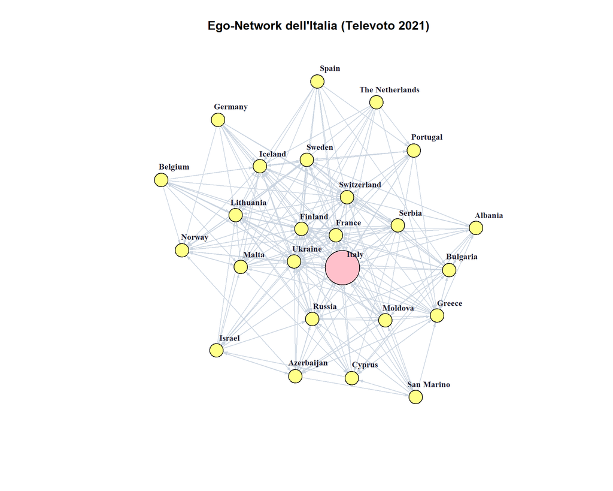

L’Ego-Network mostra la coesistenza pacifica e la convergenza ravviciata di nazioni storicamente divise nei blocchi di voto tradizionali dell’Eurovision. Troviamo infatti legati allo stesso nodo centrale sia i paesi del blocco post-sovietico (Russia, Ucraina, Azerbaigian, Moldavia) e dell’estrazione balcanica (Serbia, Bulgaria, Albania, Grecia), sia i membri storici del blocco occidentale e scandinavo (Francia, Spagna, Svizzera, Paesi Bassi, Svezia, Islanda, Belgio).

## 2.7 Rete Multilayer

Per comprendere appieno l’evoluzione temporale dei flussi di voto, l’analisi è stata estesa a una struttura di Network Multilayer (Rete Multistrato). A differenza di una rete classica (monolayer), una rete multilayer permette di mappare le relazioni tra le entità tenendo conto di diversi contesti, canali o, come in questo caso specifico, archi temporali distinti (gli anni delle edizioni).

1. I Nodi nella Rete Multilayer Nelle reti multistrato è fondamentale distinguere tra l’entità fisica/astratta in sé e la sua rappresentazione all’interno di un determinato strato:
- **Entità (o Attori*)**: Rappresentano gli Stati partecipanti (es. Italia, Francia, Ucraina). Il set di attori rimane globalmente lo stesso o varia leggermente tra le edizioni.
- **Nodi di Layer (Node-Layer Pairs)**: Un nodo è definito dalla combinazione dell’attore e dello strato in cui si trova (es. Italy 2018, Italy 2019, Italy 2021). Nella visualizzazione grafica, questi nodi compaiono replicati sui tre piani paralleli.
2. Gli Archi (Links) nella Rete Multilayer La complessità e la ricchezza della rete multilayer risiedono nella presenza di due macro-tipologie di archi:
- **Archi Intra-layer (Intra-strato)**: Sono i collegamenti che avvengono all’interno dello stesso strato temporale. Nel caso del televoto, rappresentano i flussi di voti scambiati tra le nazioni durante una specifica edizione (es. i voti inviati dall’Albania all’Italia nel 2019). Questi archi sono diretti e pesati in base all’intensità del televoto.
- **Archi Inter-layer (Inter-strato)**: Sono i collegamenti verticali che uniscono strati diversi. Nel modello longitudinale utilizzato (chiamato Multiplex o Rete Temporale), gli archi inter-layer collegano la stessa identica entità con se stessa nel corso del tempo (es. il filo conduttore ideale o la linea tratteggiata che unisce Italy 2018 a Italy 2019 e poi a Italy 2021). Questi archi fungono da “ancore” strutturali e permettono di misurare la stabilità del comportamento di uno Stato nel tempo.
3. Misure di Centralità e Metriche nelle Reti Multilayer Le classiche metriche di network science vengono riadattate matematicamente per considerare la presenza dei layer:
- **Multilayer Degree (Grado Multistrato)** e In-Degree longitudinale: Mentre in una rete classica l’In-Degree indica quanti voti riceve un paese in un anno, l’In-Degree Multistrato può calcolare la centralità complessiva di un paese sommando i voti ricevuti attraverso tutti i layer (il grado aggregato), permettendo di identificare i paesi storicamente più forti al televoto.
- **Overlapping Degree (Grado di Sovrapposizione)**: Misura la persistenza dei collegamenti di un nodo. Se l’Italia riceve costantemente voti alti dagli stessi paesi sia nel 2018, sia nel 2019 che nel 2021, l’arco intra-layer si “sovrappone” nei vari strati, indicando la presenza di alleanze geopolitiche o preferenze culturali storiche e non passeggere.
- **Centralità Multilayer**: Valuta l’importanza di uno Stato non solo all’interno di una singola edizione, ma calcolando l’influenza che si propaga attraverso i collegamenti temporali inter-layer. Un paese è centrale se riceve voti da paesi a loro volta centrali storicamente nel sistema Eurovision.

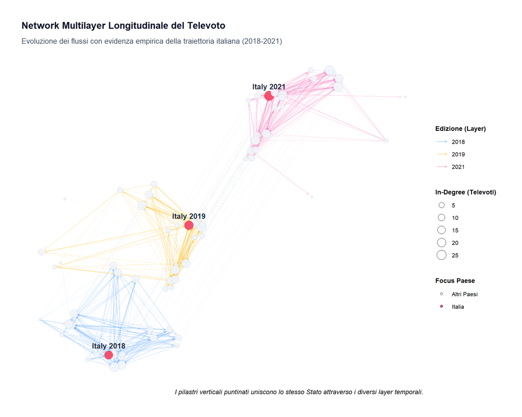

L’algoritmo di disposizione spaziale (layout) ha raggruppato i nodi in tre macro-cluster nettamente separati, identificati dai colori delle linee: blu in basso (2018), giallo al centro (2019) e fucsia in alto (2021). Questa forte separazione geometrica dimostra che i flussi di voto interni a ciascuna annata sono estremamente densi. Le preferenze del pubblico sono cioè fortemente condizionate dal contesto e dai brani in gara in quel preciso anno, creando strutture comunitarie temporanee che si chiudono in se stesse all’interno del singolo strato. Le linee verticali tratteggiate in grigio chiaro rappresentano i legami inter-layer, ovvero i canali che collegano ogni singolo Stato a se stesso nel corso del tempo. Visivamente, questi pilastri fungono da “ancore” strutturali: mantengono i tre piani allineati e dimostrano che, nonostante i flussi di voto cambino drasticamente da un anno all’altro a seconda delle canzoni, esiste una memoria storica sotterranea che stabilizza la rete sul piano longitudinale.

- **Italy 2018 (Layer Blu)**: Si colloca nella parte inferiore del primo cluster. Presenta una dimensione del nodo medio-piccola e si trova in una posizione periferica rispetto al nucleo centrale blu. Questo indica che nel 2018 l’In-Degree (la quantità di televoti ricevuti) era contenuto e proveniva da una sotto-rete ristretta di partner.
- **Italy 2019 (Layer Giallo)**: Nel piano centrale, il nodo subisce una contrazione spaziale verso destra, andandosi a posizionare sul margine destro di un ammasso di nodi estremamente fitto e compatto. In termini di rete, questa forte vicinanza geometrica indica un cluster ad altissima densità: l’Italia si trova al centro di un blocco di paesi con comportamenti di voto altamente reciproci, stabili e concentrati.
- **Italy 2021 (Layer Fucsia)**: Il cluster fucsia del 2021 si sviluppa lungo una struttura diagonale fortemente allungata. La forma allungata del piano del 2021 mostra che la rete si è polarizzata su due poli opposti (estremità destra ed estremità sinistra). La posizione dell’Italia sul lato sinistro indica che il paese esercita (e subisce) una forza di attrazione magnetica specifica verso quella metà del network. L’Italia è circondata da un folto gruppo di nodi a brevissima distanza geometrica, che indica un’altissima densità locale di relazioni. Nello spazio del grafo, questa vicinanza significa che l’Italia condivide con i paesi limitrofi la stessa identica rete di flussi.

I dati visivi dimostrano che la vittoria dell’Italia nel 2021 non si è configurata come un’anomalia statistica isolata (che avrebbe generato un singolo nodo gigante e staccato da tutto), ma come un fenomeno di polarizzazione collettiva. Il brano ha spinto un intero macro-blocco di paesi del layer fucsia a convergere verso la stessa direzione spaziale, espandendo la ragnatela dei flussi di voto e distribuendo la centralità in modo più diffuso rispetto alla forte chiusura geopolitica osservata nel cluster giallo del 2019.

# 3 PARTE II: TEXT MINING

## 3.1 Sentiment Analysis globale

La struttura semantica globale dell’Eurovision 2021 è governata da una netta prevalenza dell’asse positivo, dove i picchi gemelli di Gioia e Fiducia confermano la natura intrinsecamente aggregativa e ottimista del festival, storicamente orientata alla celebrazione e alla coesione linguistica e culturale. Questa spinta ideale è sostenuta da un’elevata dose di Anticipazione, che introduce nei testi una forte tensione narrativa verso il futuro, il cambiamento e la rivalsa generazionale, tipica delle strutture ritmiche della musica pop contemporanea.

Le componenti più drammatiche, rappresentate da Tristezza e Paura, si attestano su un livello intermedio e perfettamente bilanciato. Questo equilibrio dimostra che il corpus non scade mai in una linearità banale, ma accoglie una stratificazione espressiva capace di dare voce anche a intime confessioni personali o a ballad malinconiche. Al contrario, le emozioni più viscerali e respingenti dello spettro di Plutchik, come Rabbia e Disgusto, rimangono nettamente confinate sul fondo della classifica, a testimonianza del fatto che l’aggressività e la rottura semantica radicale siano rimaste scelte stilistiche d’élite, circoscritte a pochissimi brani di rottura come quello dell’Italia.

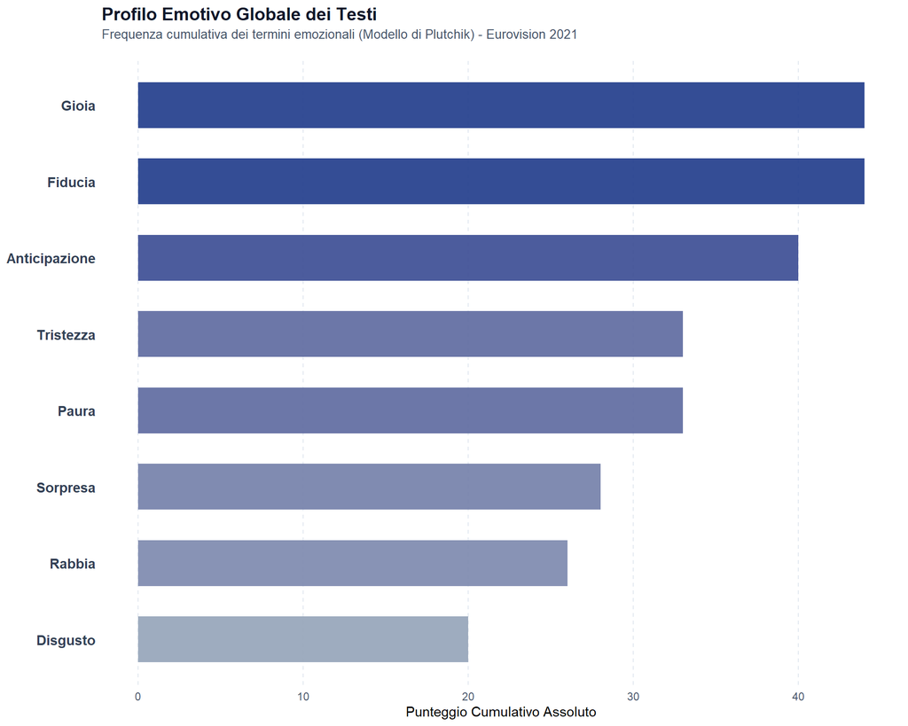

## 3.2 Sentiment Analysis TOP 3

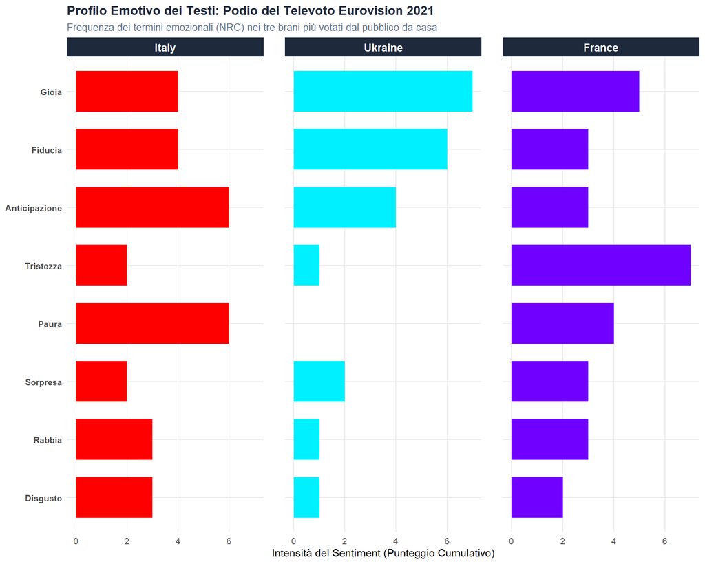

Il successo al televoto nell’Eurovision 2021 non è stato guidato da un unico standard testuale, ma dalla polarizzazione di tre “impronte digitali emotive” radicalmente contrapposte. L’algoritmo NRC mostra come i tre paesi sul podio abbiano intercettato il favore del pubblico battendo strade semantiche completamente differenti.

## 3.3 Analisi delle corrispondenze

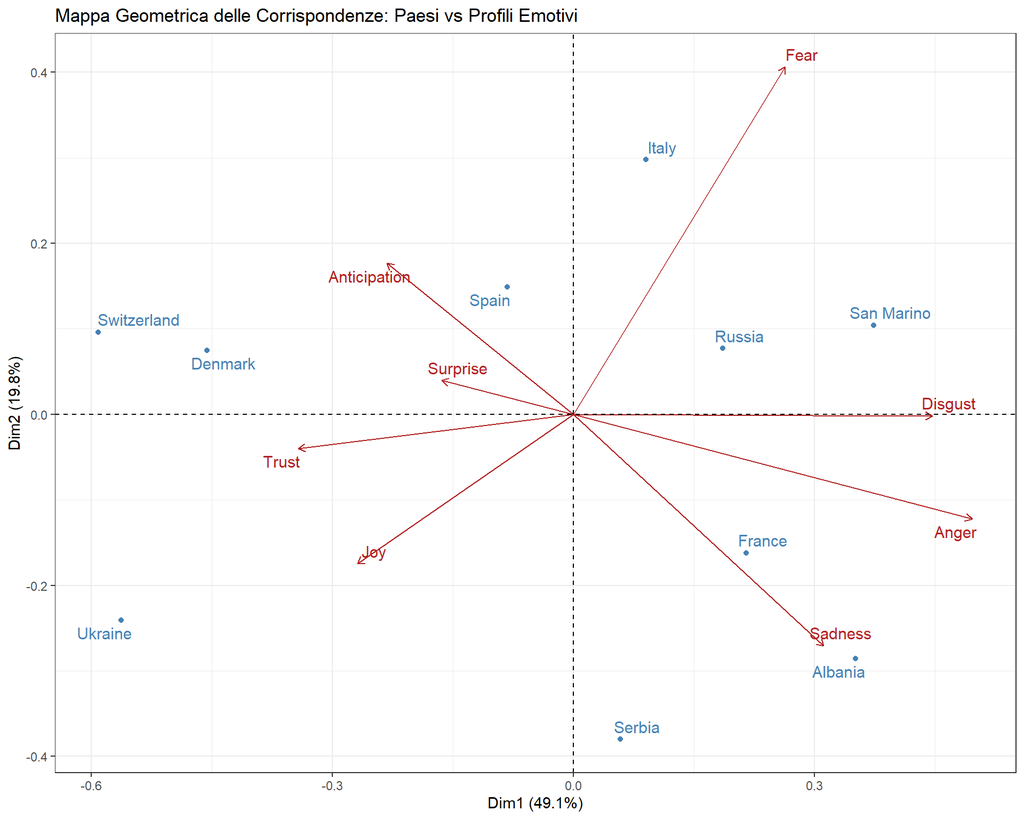

Per garantire la massima efficacia interpretativa e isolare i reali pattern artistici, lo spazio geometrico è stato filtrato escludendo i paesi posizionati in stretta prossimità dell’origine degli assi (profilo medio generalista della kermesse). Questa operazione di de-noising statistico permette di focalizzare l’analisi esclusivamente sulle nazioni che presentano un’inerzia (varianza) significativa, ovvero quelle i cui testi deviano in modo netto dalla media del festival, esprimendo una precisa e marcata identità emotiva secondo il modello di Plutchik.

La distribuzione geometrica mappa i paesi in quattro macro-aree semantiche (quadranti):